# 01_ErrorControlCoding slides

### What is error control coding?

[figure not shown]

- The second main task of coding: **error control**
- Protect information against channel errors

### Mutual information and error control

- Mutual information $I(X,Y)$ = the information transmitted on the channel
- Even though there is information transmitted on the channel, when the channel is noisy the information is **not enough**

Example: consider the following BSC channel (p = 0.01, $p(x_1) = 0.5$, $p(x_2)=0.5$):

[figure not shown]

- The receiver would like to know the source messages
  - In absence of communication, the uncertainty is $H(X) = 1$ bit/msg
  - With communication, the uncertainty is $H(X|Y) \approx 0.081$ bit/msg
  - $I(X,Y) = H(X) - H(X|Y) = \approx 0.919$ bit/msg
- Even though we have large I(X,Y), about $1\%$ of all bits are erroneuos
  - Imagine downloading a file, but having $1\%$ wrong bits

### Why is error control needed?

- In most communications it is required that *all* bits are received correctly
  - Not $1\%$ errors, not $0.1\%$, not $0.0001\%$. **None!**
- But that is not possible unless the channel is ideal.
- So what do to? **Error control coding**

### Modelling the errors on the channel

- We consider only binary channels (symbols = $\left\lbrace 0,1 \right\rbrace$)
- An error = a bit is changed from 0 to 1 or viceversa
- Changing the value of a bit = modulo-2 sum with 1
- Value of a bit remains the same = modulo-2 sum with 0

[figure not shown]

- Channel model we use (simple):
  - The transmitted sequence is summed modulo-2 with an **error sequence**
  - Where the error sequence is 1, there is a bit error
  - Where the error sequence is 0, there is no error $$\mathbf{r} = \mathbf{c} \oplus \mathbf{e}$$

### Error detection and error correction

Binary error correction:

- For binary channels, know the location of error => fix error by inverting bit
- Locating error = correcting error

Two possibilities in practice:

- **Error detection**: find out if there is any error in the received sequence
  - don't know exactly where, so cannot correct the bits, but can discard whole sequence
  - perhaps ask the sender to retransmit (examples: TCP/IP, internet communication etc)
  - easier to do
- **Error correction**: find out exactly which bits have errors, if any
  - can correct all errored bits by inverting them
  - useful when can't retransmit (data is stored: on HDD, AudioCD etc.)
  - harder to do than mere detection

### What is error control coding?

The process of error control:

1. Want to send a sequence of $k$ bits = **information word** $$\mathbf{i} = i_1i_2...i_k$$
2. For each possible information word, the coder assigns a **codeword** of length $n > k$: $$\mathbf{c} = c_1c_2...c_n$$
3. The codeword is sent on the channel instead of the original information word
4. The receiver receives a sequence $\mathbf{r} = \mathbf{c} + \mathbf{e}$, with possible errors: $$\mathbf{r} = r_1 r_2 ... r_n$$
5. The decoding algorithm detects/corrects the errors in $\mathbf{r}$

### Definitions

- An **error correcting code** is an association between the set of all possible information words to a set of codewords
  - Each possible information word $\mathbf{i}$ has a certain codeword $\mathbf{c}$
- The association can be done:
  - randomly: codewords are selected and associated randomly to the information words
  - based on a certain rule: the codeword is computed with some algorithm from the information word
- A code is a **block code** if it operates with words of *fixed size*
  - Size of information word $\mathbf{i} = k$, size of codeword $\mathbf{c} = n$, $n > k$
  - Otherwise it is a *non-block code*
- A code is **linear** if any linear combination of codewords is also a codeword
- The **coding rate** of a code is: $$R = \frac{k}{n}$$

### Definitions

- A code $C$ is an **$t$-error-detecting** code if it is able to *detect* $t$ errors
- A code $C$ is an **$t$-error-correcting** code if it is able to *correct* $t$ errors

### Hamming distance

- The **Hamming distance** of two binary sequences $a$, $b$ of length $n$ = the total number of bit differences between them $$d_H(a, b) = \sum_{i=1}^N a_i \bigoplus b_i$$
- We need at least $d_H(a, b)$ bit changes to convert one sequence into another
- It satisfies the 3 properties of a metric function:
  1. $d(a,b) \geq 0 \forall a,b$, with $d(a,b) = 0 \Leftrightarrow a = b$
  2. $d(a,b) = d(b,a), \forall a,b$
  3. $d(a,c) \leq d(a,b) + d(b,c), \forall a,b,c$
- The **minimum Hamming distance of a code**, ${d_H}_{min}$ = the minimum Hamming distance between any two codewords $\mathbf{c_1}$ and $\mathbf{c_2}$
- Example at blackboard

### Linear block codes

- A code is a **block code** if it operates with words of *fixed size*
  - Size of information word $\mathbf{i} = k$, size of codeword $\mathbf{c} = n$, $n > k$
  - Otherwise it is a *non-block code*
- A code is **linear** if any linear combination of codewords is also a codeword
- A code is called **systematic** if the codeword contains all the information bits explicitly, unaltered
  - coding merely adds supplementary bits besides the information bits
  - codeword has two parts: the information bits and the parity bits
  - example: parity bit added after the information bits
- Otherwise the code is called **non-systematic**
  - the information bits are not explicitly visible in the codeword
- Example: at blackboard

### Generator matrix

- All codewords for a linear block code can be generated via a matrix multiplication: $$\mathbf{i} \cdot [G] = \mathbf{c}$$

[figure not shown]

- $[G]$ = **generator matrix** of size $k \times n$
- All operations are done in modulo-2 arithmetic:
  - $0 \oplus 0 = 0$, $0 \oplus 1 = 1$, $1 \oplus 0 = 1$, $1 \oplus 1 = 0$
  - multiplications as usual
- Row-wise interpretation:
  - $\mathbf{c}$ = a linear combination of rows in $[G]$
  - The rows of $[G]$ = a *basis* for the linear code

### Parity check matrix

- How to check if a binary word is a codeword or not
- Every $k \times n$ generator matrix $[G]$ has complementary matrix $[H]$ such that $$0 = [H] \cdot [G]^T$$
- For every codeword $\mathbf{c}$ generated with $[G]$: $$\boxed{ 0 = [H] \cdot \mathbf{c}^T }$$
- because: $$\mathbf{i} \cdot [G] = \mathbf{c}$$ $$[G]^T \cdot \mathbf{i}^T = \mathbf{c}^T$$ $$[H] \cdot \mathbf{c}^T = [H] \cdot [G]^T \cdot \mathbf{i}^T = 0$$

### Parity check matrix

- $[H]$ is the **parity-check matrix**, size = $(n-k) \times n$
- $[G]$ and $[H]$ are related, one can be deduced from the other
- The resulting vector $z = [H] \cdot [c]^T$ is the **syndrome**
- All codewords generated with $[G]$ will produce $0$ when multiplied with $[H]$
- All binary sequences that are not codewords will produce $\neq 0$ when multiplied with $[H]$
- Column-wise interpretation of multiplication:

[figure not shown]

### [G] and [H] for systematic codes

- For systematic codes, [G] and [H] have special forms
- Generator matrix
  - first part = some matrix $Q$
  - second part = identity matrix

$$[G]_{k \times n} = [Q_{k \times (n-k)} \;\; I_{k \times k}]$$

- Parity-check matrix
  - first part = identity matrix
  - second part = same Q, transposed

$$[H]_{(n-k) \times n} = [I_{(n-k) \times (n-k)} \;\; Q^T_{(n-k) \times k}]$$

- Can easily compute one from the other
- Example at blackboard

### Syndrome-based error detection

Syndrome-based error *detection* for linear block codes:

1. generate codewords with generator matrix: $$\mathbf{i} \cdot [G] = \mathbf{c}$$
2. send codeword $\mathbf{c}$ on the channel
3. random error word $\mathbf{e}$ is applied on the channel
4. receive word $\mathbf{r} = \mathbf{c} \oplus \mathbf{e}$
5. compute **syndrome** of $\mathbf{r}$: $$\mathbf{z} = [H] \cdot \mathbf{r}^T$$
6. Decide:
   - If $\mathbf{z} = 0$ => $\mathbf{r}$ has no errors
   - If $\mathbf{z} \neq 0$ => $\mathbf{r}$ has errors

### Syndrome-based error correction

Syndrome-based error *correction* for linear block codes:

- $\mathbf{z} \neq 0$ => $\mathbf{r}$ has errors, we need to locate them
- The syndrome is the effect only of the error word: $$\mathbf{z} = [H] \cdot \mathbf{r}^T = [H] \cdot (\mathbf{c}^T \oplus \mathbf{e}^T) = [H] \cdot \mathbf{e}^T$$
- Create a **syndrome lookup table**:
  - for every possible error word $\mathbf{e}$, compute the syndrome $\mathbf{z} = [H] \cdot \mathbf{e}^T$
  - start with error words with 1 error (most likely), then with 2 errors (less likely), and so on
- Locate the syndrome $\mathbf{z}$ in the table, read the corresponding error word $\mathbf{\hat{e}}$
- Find the correct word:
  - adding the error word again will invert the errored bits back to the originals $$\mathbf{\hat{c}} = \mathbf{r} \oplus \mathbf{\hat{e}}$$

### Summing up

Summing up until now:

- Linear block codes use a generator matrix $G$ for encoding, and a parity-check matrix $H$ for checking the received word.

### Hamming codes

- A particular class of linear error-correcting codes
- Definition: a **Hamming code** is a linear block code where the columns of $[H]$ are *the binary representation of all numbers from 1 to $2^r-1$*, $\forall r \geq 2$
- Example (blackboard): (7,4) Hamming code
- Systematic: arrange the bits in the codeword, such that the control bits correspond to the columns having a single 1
  - no big difference from the usual systematic case, just a rearrangement of bits
  - makes implementation easier
- Example codeword for Hamming(7,4): $$c_1c_2i_3c_4i_5i_6i_7$$

### Properties of Hamming codes

- From definition of $[H]$ it follows:
  1. Codeword has length $n = 2^r - 1$
  2. $r$ bits are parity bits (also known as *control bits*)
  3. $k = 2^r-r-1$ bits are information bits
- Notation: **(n,k) Hamming code**
  - n = codeword length = $2^r-1$,
  - k = number of information bits = $2^r - r - 1$
  - Example: (7,4) Hamming code, (15,11) Hamming code, $(127,120)$ Hamming code

### Properties of Hamming codes

- Can detect two errors
  - All columns are different => can detect 2 errors
  - Sum of two columns equal to a third => cannot correct 3

**OR**

- Can correct one error
  - All columns are different => can correct 1 error
  - Sum of two columns equal to a third => cannot correct 2
  - Non-systematic: syndrome = error position

**BUT**

- Not simultaneously!
  - same non-zero syndrome can be obtained with 1 or 2 errors, can't distinguish

### Coding rate of Hamming codes

Coding rate of a Hamming code: $$R = \frac{k}{n} = \frac{2^r - r - 1}{2^r-1}$$

The Hamming codes can correct 1 OR detect 2 errors in a codeword of size $n$

- (7,4) Hamming code: $n = 7$
- (15,11) Hamming code: $n = 15$
- (31,26) Hamming code: $n = 31$

Longer Hamming codes are progressively weaker:

- weaker error correction capability
- better efficiency (higher coding rate)
- more appropriate for smaller error probabilities

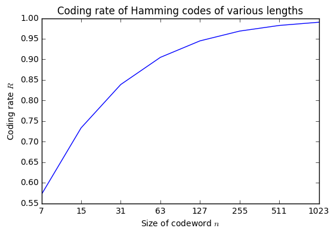

```python
%matplotlib inline
import numpy as np, matplotlib.pyplot as plt
r = np.array([3., 4., 5., 6., 7., 8., 9., 10.])
k = 2**r - r - 1
n = 2**r-1
R = k/n
plt.plot(r, R)
plt.xticks(r, [str(int(i)) for i in n])
plt.title('Coding rate of Hamming codes of various lengths')
plt.xlabel('Size of codeword $n$')
plt.ylabel('Coding rate $R$')
```

### Encoding & decoding example for Hamming(7,4)

See whiteboard.

In this example, encoding is done without the generator matrix $G$, directly with the matrix $H$, by finding the values of the parity bits $c_1$, $c_2$, $c_4$ such that $$\begin{bmatrix}0\\0\\0\end{bmatrix} = [H] \begin{bmatrix}c_1\\c_2\\i_3\\c_4\\i_5\\i_6\\i_7\end{bmatrix}$$

For a single error, the syndrome **is the binary representation of the location of the error**.

### Circuits for encoding and decoding Hamming(7,4)

At whiteboard, using **shift registers**.

### SECDED Hamming codes

Hamming codes can correct 1 error OR can detect 2 errors, but we cannot differentiate the two cases:

Example:

- the syndrome $\mathbf{z} = [H] \cdot \mathbf{r}^T = \begin{bmatrix}0\\1\\1\end{bmatrix}$ can be caused by:
  - a single error in location 3 (bit $i_3$)
  - two errors in location 1 and 2 (bits $c_1$, bits $c_2$)
- if we know it is a single error, we can go ahead and correct it, then use the corrected data
- if we know there are two errors, we should NOT attempt to correct them, because we cannot locate the errors correctly

Unfortunately, it is **not possible to differentiate** between the two cases.

**Solution?** Add additional parity bit $\rightarrow$ SECDED Hamming codes

### SECDED Hamming codes

- Add an additional parity bit to differentiate the two cases
  - $c_0$ = sum of all $n$ bits of the codeword
- For (7,4) Hamming codes: $$\mathbf{c_0}c_1c_2i_3c_4i_5i_6i_7$$
- The pairty check matrix is extended by 1 row and 1 column $$\tilde{H} = \begin{bmatrix} 1 &1 \\ 0 &\mathbf{H} \\ \end{bmatrix}$$
- Known as SECDED Hamming codes
  - **S**ingle **E**rror **C**orrection - **D**ouble **E**rror **D**etection

### Encoding and decoding of SECDED Hamming codes

#### Encoding

- compute codeword using $\tilde{H}$

#### Decoding

- Compute syndrome of the received word using $\tilde{H}$ $$\tilde{\mathbf{z}} = \begin{bmatrix}z_0\\\mathbf{z}\end{bmatrix} = [\tilde{H}] \cdot \mathbf{r}^T$$
- $z_0$ is an additional bit in the syndrome corresponding to $c_0$
- $z_0$ tells us whether the received $c_0$ matches the paroty of the received word
  - $z_0 = 0$: the additional parity bit matches the parity of the received word
  - $z_0 = 1$: the additional parity bit does not match the parity of the received word

#### Decide which of the following cases happened

- If no error happened: $z_1 = z_2 = z_3 = 0, z_0 = \forall$
- If 1 error happened: syndrome is non-zero, $z_0 = 1$ (does not match)
- If 2 errors happened: syndrome is non-zero, $z_0 = 0$ (does match, because the two errors cancel each other out)
- If 3 errors happened: same as 1, can't differentiate
- Now can simultaneously differentiate between:
  - 1 error: $\rightarrow$ perform correction
  - 2 errors: $\rightarrow$ detect, but do not perform correction
- Also, if correction is never attempted, can detect up to 3 errors
  - minimum Hamming distance = 4 (no proof given)
  - don't know if 1 error, 2 errors or 3 errors, so can't try correction

### Circuits for encoding and decoding SECDED Hamming codes

At whiteboard. Slight modification of the previous schematic to accommodate the extra parity bit.

### Summary until now

- Systematic codes: information bits + parity bits
- Generator matrix: use to generate codeword $$\mathbf{i} \cdot [G] = \mathbf{c}$$
- Parity-check matrix: use to check if a codeword $$0 = [H] \cdot \mathbf{c}^T$$
- Syndrome: $$\mathbf{z} = [H] \cdot \mathbf{r}^T$$
- Syndrome-based error detection: syndrome non-zero
- Syndrome-based error correction: lookup table
- Hamming codes: $[H]$ contains all numbers $1 ... 2^r - 1$
- SECDED Hamming codes: add an extra parity bit

## Cyclic codes

Definition:

**Cyclic codes** are a particular class of linear block codes for which *every cyclic shift of a codeword is also a codeword*

- Cyclic shift: cyclic rotation of a sequence of bits (any direction)
- Are a particular class of linear block codes, so all the theory up to now still applies
  - they have a generator matrix, parity check matrix etc.
- But they can be implemented more efficient than general linear block codes (e.g. Hamming)
- Used **everywhere** under the common name **CRC** (**C**yclic **R**edundancy **C**heck)
  - Network communications (Ethernet), data storage in Flash memory

### Binary polynomials

Every binary sequence $\mathbf{a}$ corresponds to a polynomial $\mathbf{a(x)}$ with binary coefficients $$a_0a_1...a_{n-1} \rightarrow \mathbf{a(x)} = a_0 \oplus a_1x \oplus ... \oplus a_{n-1}x^{n-1}$$

Example: $$10010111 \rightarrow 1 \oplus x^3 \oplus x^5 \oplus x^6 \oplus x^7$$

From now on, by "codeword" we also mean the corresponding polynomial.

Can perform all mathematical operations with these polynomials:

- addition, multiplication, division etc. (examples)

There are efficient circuits for performing multiplications and divisions.

### Generator polynomial

**Theorem**:

All the codewords of a cyclic code are multiples of a certain polynomial $g(x)$, known as **generator polynomial**.

Properties of generator polynomial $g(x)$:

- The generator polynomial has first and last coefficient equal to 1.
- The generator polynomial is a factor of $X^n \oplus 1$
- The *degree* of $g(x)$ is $n-k$, where:
  - The codeword = polynomial of degree $n-1$ ($n$ coefficients)
  - The information polynomial = polynomial of degree $k-1$ ($k$ coefficients) $$ (k-1) + (n-k) = n-1$$
- **The degree of $g(x)$ is the number of parity bits of the code.**

### Finding a generator polynomial

**Theorem**:

If $g(x)$ is a polynomial of degree $(n-k)$ and is a factor of $X^n \oplus 1$, then $g(x)$ generates a $(n,k)$ cyclic code.

Example:

$$1 \oplus x^7 = (1 \oplus x)(1 \oplus x + \oplus x^3)(1 \oplus x^2 \oplus x^3)$$

Each factor generates a code:

- $1 \oplus x$ generates a (7,6) cyclic code
- $1 \oplus x \oplus x^3$ generates a (7,4) cyclic code
- $1 \oplus x^2 \oplus x^3$ generates a (7,4) cyclic code

### Computing the codewords

Start from information polynomial with $k$ bits $$i(x) = i_0 \oplus i_1x \oplus ... \oplus i_{k-1}x^{k-1}$$

**Non-systematic** codeword generation:

- Codeword = $i(x) \cdot g(x)$

$$\boxed{c(x) = i(x) \cdot g(x)}$$

**Systematic** codeword generation:

$$\boxed{c(x) = b(x) \oplus x^{n-k}i(x)}$$

where $b(x)$ is the remainder of dividing $x^{n-k} i(x)$ to $g(x)$: $$x^{n-k} i(x) = a(x) g(x) \oplus b(x)$$

- (Proof: at blackboard)

### Proving the cyclic property

We prove that any cyclic shift of a codeword is also a codeword.

Proof: at whiteboard

- Original codeword $$c_0c_1c_2...c_{n-1} \rightarrow \mathbf{c(x)} = c_0 \oplus c_1x \oplus ... \oplus c_{n-1}x^{n-1}$$
- Cyclic shift to the right by 1 position $$c_{n-1}c_0c_1...c_{n-2} \rightarrow \mathbf{c'(x)} = c_{n-1} \oplus c_0x \oplus ... \oplus c_{n-2}x^{n-1}$$
- Note that $$\begin{split} \mathbf{c'(x)} =& x \cdot \mathbf{c(x)} \oplus c_{n-1}x^n \oplus c_{n-1}\\ =& x \cdot \mathbf{c(x)} \oplus c_{n-1}(x^n \oplus 1)\\ \end{split}$$

Since $\mathbf{c(x)}$ is a multiple of $g(x)$, so is $x \cdot \mathbf{c(x)}$. Also $(x^n \oplus 1)$ is always a multiple of $g(x)$. It follows that their sum $\mathbf{c'(x)}$ is a also a multiple of $g(x)$, which means it is a codeword.

### Cyclic code encoder circuits

- Coding = based on polynomial multiplications and divisions
- Efficient circuits for multiplication / division exist
- Similar circuit exists for systematic codeword generation (draw on blackboard)

### Circuits for multiplication of binary polynomials

[figure not shown]

### Circuits for division binary polynomials

[figure not shown]

### Error detection with cyclic codes

- Like usual for linear codes: check if received word is codeword or not
- Every codeword is multiple of $g(x)$
- Check if received word is actually dividing with $g(x)$
  - Use a circuit for division of polynomials
- If remainder is 0 => it is a codeword, no error
- If remainder is non-0 => error detected!
- Cyclic codes have very good error detection capabilities

### Error correction capability

**Theorem**:

Any (n,k) cyclic codes is capable of detecting any error **burst** of length $n-k$ or less.

- A large fraction of longer bursts can also be detected (but not all)
- For non-burst errors (random): more difficult to analyze

### Error correction with cyclic codes

- Like usual for linear codes: lookup table based on remainder
- Remainder of division = the effect of the error polynomial
- Create lookup table: for every error word, compute remainder
- Search the table for the remainder of the received word => find error word

### Summary of cyclic codes

- Generated using a generator polynomial $g(x)$
- Non-systematic: $$c(x) = i(x) \cdot g(x)$$
- Systematic: $$c(x) = b(x) \oplus X^{n-k}i(x)$$
  - $b(x)$ is the remainder of dividing $X^{n-k} i(x)$ to $g(x)$
- Syndrome = remainder of division $r(x)$ to $g(x)$
- Error detection: remainder (syndrome) non-zero
- Error correction: lookup table